# P6

Amalia Tsakali

2022-10-30

Libraries and seed

```r
library(MASS)
library(ISLR)
library(tidyverse)
library(pROC)
```

```r
library(rpart)
library(rpart.plot)
library(randomForest)
set.seed(45)
```

##Confusion matrix, continued 1.Create a logistic regression model lr_mod for this data using the formula response ~ . and create a confusion matrix based on a .5 cutoff probability.

```r
patients<-read.csv("data/cardiovascular_treatment.csv")
head(patients)
```

```
##   severity      age gender  bb_score prior_cvd dose response
## 1     high 54.76957      m 349.51705         0    2        1
## 2      low 59.48023      f  99.74619         0    2        0
## 3      low 55.43236      f 444.73453         0    2        0
## 4      low 48.16994      f 152.69093         0    2        1
## 5      low 54.49713      f 251.40971         1    2        0
## 6      low 40.72455      m 349.12893         0    2        1
```

```r
patients<-patients %>%   mutate(severity = as.factor(severity), gender   = as.factor(gender), dose     = as.factor(dose), response = as.factor(response))
lr_mod<-glm(response~., "binomial", patients)
lr_pred<-predict(lr_mod,type="response")
lr_pred<-ifelse(lr_pred>0.5,"1","0")
table(observed=patients$response, pred=lr_pred)
```

```
##         pred
## observed  0  1
##        0 80 47
##        1 29 97
```

2.Calculate the accuracy, true positive rate (sensitivity), the true negative rate (specificity), the false positive rate, the positive predictive value, and the negative predictive value. You can use the confusion matrix table on wikipedia. What can you say about the model performance? Which metrics are most relevant if this model were to be used in the real world?

```r
#accuracy

#TP rate
#FP rate
#PPV
#NPV
TP<-97
TN<-80
FP<-47
FN<-29
#true positive rate
print("TP rate")
```

```
## [1] "TP rate"
```

```r
TP/(TP+FN)
```

```
## [1] 0.7698413
```

```r
#true negative
print("TN rate")
```

```
## [1] "TN rate"
```

```r
TN/(TN+FP)
```

```
## [1] 0.6299213
```

```r
#false positive
print("FP rate")
```

```
## [1] "FP rate"
```

```r
FP/(FP+TN)
```

```
## [1] 0.3700787
```

```r
#accuracy
print("accuracy")
```

```
## [1] "accuracy"
```

```r
(TP+TN)/(TP+TN+FP+FN)
```

```
## [1] 0.6996047
```

```r
#Positive predictive value
print("PPV")
```

```
## [1] "PPV"
```

```r
TP/(TP+FP)
```

```
## [1] 0.6736111
```

```r
#Negative predictive value
print("NPV")
```

```
## [1] "NPV"
```

```r
TN/(TN+FN)
```

```
## [1] 0.733945
```

```r
# the accuracy of the model is a bit below 70%, so we predict correctly 70% of the time
# our model is better at predicting the positive response to treatment TP>TN
#The is a 37 % of predicting a positive response when there is not (FP rate)
#out of all the positive predictions of our model 67% are correct
#out of all the negative 73% are correct
# that leads us to believe that our model is slightly more eager to classify something as a positive response

# The last two metrics are very relevant: if a new patient comes in you only know the prediction and not the true value
```

3.Create an LDA model lda_mod for the same prediction problem. Compare its performance to the LR model.

```r
lda_mod<-lda(response~., patients)
lda_pred<-predict(lda_mod)
table(true = patients$response, pred = lda_pred$class)
```

```
##     pred
## true  0  1
##    0 80 47
##    1 29 97
```

```r
#the performance is exactly the same (same confusion matrix)
```

4.Compare the classification performance of lr_mod and lda_mod for the new patients in the data/new_patients.csv.

```r
new_patients<-read.csv("data/new_patients.csv") %>%   mutate(severity = as.factor(severity), gender = as.factor(gender), dose = as.factor(dose), response = as.factor(response))
new_log<-predict(lr_mod, "response", newdata = new_patients)
new_log<-ifelse(new_log > .5, 1, 0)
new_lda<-predict(lda_mod, newdata=new_patients)

table(observed=new_patients$response,pred=new_log)
```

```
##         pred
## observed  0  1
##        0 16 11
##        1  9 14
```

```r
table(observed=new_patients$response,pred=new_lda$class)
```

```
##         pred
## observed  0  1
##        0 16 11
##        1  9 14
```

```r
#exactly the same confusion matrix
```

##Brier score Calculate the out-of-sample brier score for the lr_mod and give an interpretation of this number.

```r
#Brier = MSE with 0 and 1

new_log<-predict(lr_mod, "response", newdata = new_patients)
mean((new_log - (as.numeric(new_patients$response)-1))^2)
```

```
## [1] 0.2283307
```

```r
#Mean Squared Error between the true class and the predicted
```

##ROC curve 5.Create two LR models: lr1_mod with severity, age, and bb_score as predictors, and lr2_mod with the formula response ~ age + I(age^2) + gender + bb_score * prior_cvd * dose. Save the predicted probabilities on the training data.

```r
lr1_mod<-glm(response~ severity + age +bb_score, "binomial", data=patients)
lr2_mod<-glm(response ~ age + I(age^2) + gender + bb_score * prior_cvd * dose, "binomial", data=patients)

lr1_prob<-predict(lr1_mod,type="response")
lr2_prob<-predict(lr2_mod, type="response")
```

6.Use the function roc() from the pROC package to create two ROC objects with the predicted probabilities: roc_lr1 and roc_lr2. Use the ggroc() method on these objects to create an ROC curve plot for each. Which model performs better? Why?

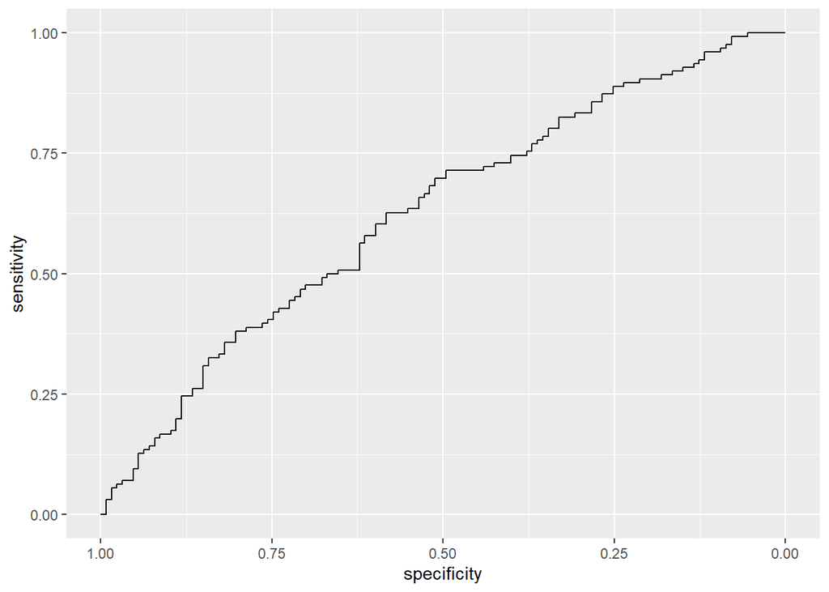

```r
roc_lr1<-roc(patients$response,lr1_prob)
roc_lr2<-roc(patients$response,lr2_prob)
ggroc(roc_lr1)
```

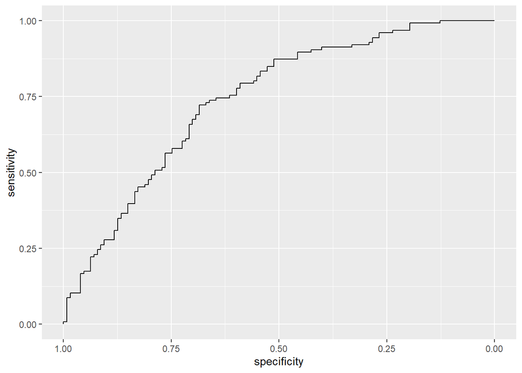

```r
ggroc(roc_lr2)
```